# Cálculo de vida útil restante en maquinaria mediante técnicas de Inteligencia Artificial Parte 1

Autor: Iñigo Rekalde Fecha: 28-02-2019

Preparación del entorno

```r
# Fijar el directorio de trabajo
setwd("~/Personal/Master/TFM/R/Def")

# Instalar las librerias si no están instaladas
# install.packages("paquete")
# Cargar librerias
library(dplyr)
library(zoo)
library(ggplot2)
library(reshape2)
library(caret)
```

Preparación para importar

```r
# Los datos a importar no contienen cabeceras.
# Se genera un vector con nombres de las columnas. Train y test comparten columnas.
col_nombres <- c("unit_num","time_cycles","ope_set1","ope_set2","ope_set3",
              "sen1","sen2","sen3","sen4","sen5","sen6","sen7","sen8","sen9","sen10",
              "sen11","sen12","sen13","sen14","sen15","sen16","sen17","sen18","sen19","sen20","sen21")
# Columna de RUL de test
col_RUL <- c("RUL")
# Para facilitar la importación se establecen los tipos de datos por columna.
# Las dos primeras son enteros y las restantes son numericas para train y test
col_tipos <- rep("integer", 2)
col_tipos <- c(col_tipos, rep("numeric", 24))
# RUL como númerica
col_tipo_RUL <- c("numeric")
```

Importación de los ficheros: Datos juego 1 de entrenamiento, test y RUL verdadero Test

```r
# Se importa el fichero para entrenar los modelos en un data frame
dftrain1 <- read.table("train_FD001.txt", col.names = col_nombres, colClasses = col_tipos)
# Se importa el fichero para test o validación en un dataframe
dftest1 <- read.table("test_FD001.txt", col.names = col_nombres, colClasses = col_tipos)
# Se importa el fichero con el RUL de test o validación
dfRUL1 <- read.table("RUL_FD001.txt", col.names = col_RUL, colClasses = col_tipo_RUL)
```

Fichero de Test 1 solo quedarse con el último registro de cada motor

```r
dftest1ult <- merge(aggregate(time_cycles~unit_num, dftest1,function(x) x[which.max(x)]),dftest1)
# Ordenarlo por número de motor
dftest1ult <- dftest1ult[with(dftest1ult, order(unit_num)), ]
```

Normalizar Juego de datos 1

```r
# Generar el modelo de normalizar
normalizardf1 <- preProcess(dftrain1, method = "range", rangeBounds = c(0,1))
```

```
No variation for for: ope_set3, sen1, sen5, sen10, sen16, sen18, sen19
```

```r
# No variation for for: ope_set3, sen1, sen5, sen10, sen16, sen18, sen19
# Normalizar el fichero de entrenamiento
dftrain1norm <- predict(normalizardf1, dftrain1)
# Normalizar el fichero de test
dftest1norm <- predict(normalizardf1, dftest1)
# Normalizar el fichero de test con un único registro por motor
dftest1ultnorm <- predict(normalizardf1, dftest1ult)
```

Eliminar las variables que no varian en el juego de entrenamiento

```r
dftrain1norvar <- dftrain1norm[ , -which(names(dftrain1norm) %in% c("ope_set3", "sen1", "sen5", "sen10", "sen16", "sen18", "sen19"))]
```

Gráfico Motor 1 Ciclo 1 sin normalizar

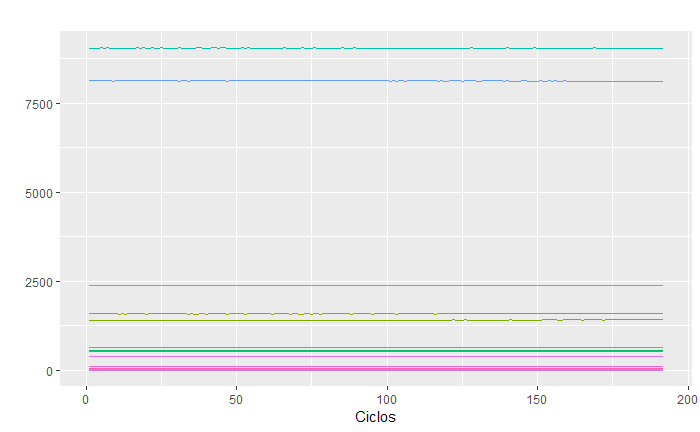

```r
gdf <- melt(dftrain1[dftrain1$unit_num == 1, !names(dftrain1) %in% c("unit_num","RUL")], id.vars="time_cycles")
grafico1 <- ggplot(gdf, aes( x=time_cycles, y=value, colour=variable , group=variable))+
  geom_line()+labs(title = "", x = "Ciclos", y = "")+
  theme(plot.title = element_text(hjust = 0.5))+
  guides(color="none")
grafico1
```

Gráfico Motor 1 Ciclo 1 datos normalizados

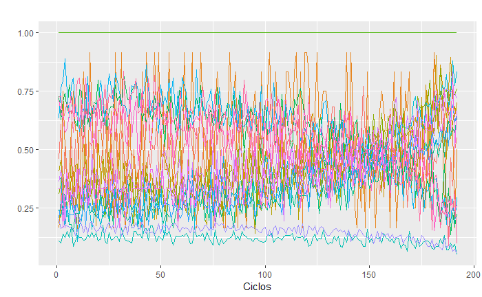

```r
dftrain1normgraf <- dftrain1norvar
dftrain1normgraf$time_cycles <- dftrain1$time_cycles
dftrain1normgraf <- melt(dftrain1normgraf[dftrain1normgraf$unit_num == 0, names(dftrain1normgraf) != "unit_num"],id.vars="time_cycles")
grafico1norm <- ggplot(dftrain1normgraf, aes( x=time_cycles, y=value, colour=variable , group=variable))+
  geom_line()+labs(title = "", x = "Ciclos", y = "")+
  theme(plot.title = element_text(hjust = 0.5))+
  guides(color="none")
grafico1norm
```

Agregar al dataframe training 1 vida Util restante (RUL)

```r
# Se generan la vida Util restante RUL para el fichero de entrenamiento
# Primero se calcula cual es el ultimo ciclo de cada motor
por_motor <- group_by(dftrain1, unit_num)
limitemotor <- summarise (por_motor, fin_vida=max(time_cycles))
# se Genera una copia
dftrain1RUL <- dftrain1
# Se agrega temporalmente una columna con el limite de cada motor
dftrain1RUL$fin_vida <- limitemotor$fin_vida[match(dftrain1RUL$unit_num, limitemotor$unit_num)]
# Se calcula la vida restante a partir del limite de fin de vida y del ciclo actual
dftrain1RUL$RUL <- dftrain1RUL$fin_vida - dftrain1RUL$time_cycles
# Se elimina la columna del limite de fin de vida
dftrain1RUL$fin_vida <- NULL
```

Prueba 01a Random Forest Normalización: - Sin normalizar. - Sin eliminar datos que no varian  
- Juego de datos 1 - Random Forest - Solo sensores. - 1 parametro. - Metodo: oob - Metrica RMSE - Arboles: 8

```r
# Parametros de control
control01 <- trainControl(
  method = "oob")
# Valor para la semilla a la hora de generar numeros aleatorios y que tenga repetitibilidad
set.seed(128)
# Generación del modelo
modelo_rf01 = train(RUL ~ ., data=dftrain1RUL,
                          method='rf',
                          preProcess=NULL,
                          metric = "RMSE",
                          replace = TRUE,
                          tuneLength = 1,
                          ntree = 8,
                          importance=T,
                          trControl = control01)
```

Resultados entrenamiento:

```r
print(modelo_rf01)
```

```
Random Forest

20631 samples
   26 predictor

No pre-processing
Resampling results:

  RMSE      Rsquared
  36.64152  0.7170112

Tuning parameter 'mtry' was held constant at a value of 5
```

Muestra la importancia de las variables

```r
varimp_rf01 <- varImp(modelo_rf01)
print(varimp_rf01)
```

```
rf variable importance

  only 20 most important variables shown (out of 26)
```

|  | Overall |
| --- | --- |
| sen8 | 100.00000 |
| sen14 | 88.18077 |
| unit_num | 60.48820 |
| sen20 | 59.82042 |
| sen13 | 53.23259 |
| time_cycles | 52.27822 |
| sen11 | 52.22726 |
| sen12 | 50.36670 |
| sen7 | 47.59820 |
| sen3 | 45.24728 |

[output cut: 10 more lines]

Genera la predicción del tiempo de vida restante sobre los datos de Test

```r
prediccion_rf01 <- predict(modelo_rf01, newdata = dftest1ult)
```

Calculo RMSE Test

```r
# Calculo RMSE Test
prediccion_ord <- prediccion_rf01[order(as.integer(names(prediccion_rf01)))]
er_test <- (prediccion_ord - dfRUL1$RUL)
RMSE_test_rf01 <- sqrt(mean(er_test^2))
print("RMSE datos Test:")
```

```
[1] "RMSE datos Test:"
```

```r
print(RMSE_test_rf01)
```

```
[1] 57.49548
```

Prueba 01b Random Forest Normalización: - Sin normalizar. - Eliminados datos que no varian  
- Juego de datos 1 - Random Forest - Solo sensores. - 1 parametro. - Metodo: oob - Metrica RMSE - Arboles: 8

```r
# Eliminar las vaariables que no varian
dftrain1RULvar <- dftrain1RUL[ , -which(names(dftrain1RUL) %in% c("ope_set3", "sen1", "sen5", "sen10", "sen16", "sen18", "sen19"))]
# Parametros de control
control01b <- trainControl(
  method = "oob")
# Valor para la semilla a la hora de generar numeros aleatorios y que tenga repetitibilidad
set.seed(128)
# Generación del modelo
modelo_rf01b = train(RUL ~ ., data=dftrain1RULvar,
                          method='rf',
                          preProcess=NULL,
                          metric = "RMSE",
                          replace = TRUE,
                          tuneLength = 1,
                          ntree = 8,
                          importance=T,
                          trControl = control01b)
```

Resultados entrenamiento:

```r
print(modelo_rf01b)
```

```
Random Forest

20631 samples
   19 predictor

No pre-processing
Resampling results:

  RMSE      Rsquared
  37.04323  0.7107722

Tuning parameter 'mtry' was held constant at a value of 4
```

Muestra la importancia de las variables:

```r
varimp_rf01b <- varImp(modelo_rf01b)
print(varimp_rf01b)
```

```
rf variable importance
```

|  | Overall |
| --- | --- |
| sen4 | 100.00000 |
| unit_num | 88.81706 |
| sen14 | 88.43793 |
| sen8 | 83.42383 |
| sen11 | 66.03128 |
| sen2 | 62.98979 |
| time_cycles | 60.23426 |
| sen21 | 51.36280 |
| sen13 | 50.26168 |
| sen3 | 47.30202 |

[output cut: 9 more lines]

Eliminar las variables que no varian en el juego de test

```r
dftest1ultvar <- dftest1ult[ , -which(names(dftest1ult) %in% c("ope_set3", "sen1", "sen5", "sen10", "sen16", "sen18", "sen19"))]
```

Genera la predicción del tiempo de vida restante sobre los datos de Test

```r
prediccion_rf01b <- predict(modelo_rf01b, newdata = dftest1ultvar)
```

Calculo RMSE Test

```r
# Calculo RMSE Test
prediccion_ord <- prediccion_rf01b[order(as.integer(names(prediccion_rf01b)))]
er_test <- (prediccion_ord - dfRUL1$RUL)
RMSE_test_rf01b <- sqrt(mean(er_test^2))
print("RMSE datos Test:")
```

```
[1] "RMSE datos Test:"
```

```r
print(RMSE_test_rf01b)
```

```
[1] 56.37411
```

Prueba 01c Random Forest Normalización: - Datos normalizados. - Sin eliminar datos que no varian  
- Juego de datos 1 - Random Forest - Solo sensores. - 1 parametro. - Metodo: oob - Metrica RMSE - Arboles: 8

```r
# Agregar el tiempor de vidar útil restante
dftrain1normRUL <- dftrain1norm
dftrain1normRUL$RUL <- dftrain1RUL$RUL
# Parametros de control
control01c <- trainControl(
  method = "oob")
# Valor para la semilla a la hora de generar numeros aleatorios y que tenga repetitibilidad
set.seed(128)
# Generación del modelo
modelo_rf01c = train(RUL ~ ., data=dftrain1normRUL,
                          method='rf',
                          preProcess=NULL,
                          metric = "RMSE",
                          replace = TRUE,
                          tuneLength = 1,
                          ntree = 8,
                          importance=T,
                          trControl = control01c)
```

Resultados:

```r
print(modelo_rf01c)
```

```
Random Forest

20631 samples
   26 predictor

No pre-processing
Resampling results:

  RMSE      Rsquared
  36.62543  0.7172597

Tuning parameter 'mtry' was held constant at a value of 5
```

Muestra la importancia de las variables:

```r
varimp_rf01c <-varImp(modelo_rf01c)
print(varimp_rf01c)
```

```
rf variable importance

  only 20 most important variables shown (out of 26)
```

|  | Overall |
| --- | --- |
| unit_num | 100.000000 |
| sen14 | 61.190327 |
| sen7 | 60.476099 |
| time_cycles | 54.489501 |
| sen12 | 47.844562 |
| sen3 | 46.523303 |
| sen9 | 40.483448 |
| sen20 | 34.012900 |
| sen2 | 32.154584 |
| sen8 | 30.358990 |

[output cut: 10 more lines]

Normaliza los datos de Test

```r
dftest1ultnorm <- predict(normalizardf1, dftest1ult)
```

Genera la predicción del tiempo de vida restante sobre los datos de Test

```r
prediccion_rf01c <- predict(modelo_rf01c, newdata = dftest1ultnorm)
```

Calculo RMSE Test

```r
# Calculo RMSE Test
prediccion_ord <- prediccion_rf01c[order(as.integer(names(prediccion_rf01c)))]
er_test <- (prediccion_ord - dfRUL1$RUL)
RMSE_test_rf01c <- sqrt(mean(er_test^2))
print("RMSE datos Test:")
```

```
[1] "RMSE datos Test:"
```

```r
print(RMSE_test_rf01c)
```

```
[1] 57.2088
```

Prueba 01d Random Forest Normalización: - Datos normalizados. - Eliminados datos que no varian  
- Juego de datos 1 - Random Forest - Solo sensores. - 1 parametro. - Metodo: oob - Metrica RMSE - Arboles: 8

```r
# Agregar el tiempor de vida útil restante
dftrain1normRULvar <- dftrain1norvar
dftrain1normRULvar$RUL <- dftrain1RUL$RUL
# Parametros de control
control01d <- trainControl(
  method = "oob")
# Valor para la semilla a la hora de generar numeros aleatorios y que tenga repetitibilidad
set.seed(128)
# Generación del modelo
modelo_rf01d = train(RUL ~ ., data=dftrain1normRULvar,
                          method='rf',
                          preProcess=NULL,
                          metric = "RMSE",
                          replace = TRUE,
                          tuneLength = 1,
                          ntree = 8,
                          importance=T,
                          trControl = control01d)
```

Resultados entrenamiento:

```r
print(modelo_rf01d)
```

```
Random Forest

20631 samples
   19 predictor

No pre-processing
Resampling results:

  RMSE      Rsquared
  36.60015  0.7176498

Tuning parameter 'mtry' was held constant at a value of 4
```

Muestra la importancia de las variables:

```r
varimp_rf01d <- varImp(modelo_rf01d)
print(varimp_rf01d)
```

```
rf variable importance
```

|  | Overall |
| --- | --- |
| unit_num | 100.000000 |
| sen13 | 87.524778 |
| sen20 | 70.042187 |
| time_cycles | 69.490236 |
| sen14 | 54.497670 |
| sen12 | 52.134570 |
| sen9 | 50.029203 |
| sen4 | 49.944961 |
| sen11 | 49.760518 |
| sen8 | 43.164425 |

[output cut: 9 more lines]

Eliminar las variables que no varian en el juego de test

```r
dftest1ultnormvar <- dftest1ultnorm[ , -which(names(dftest1ultnorm) %in% c("ope_set3", "sen1", "sen5", "sen10", "sen16", "sen18", "sen19"))]
```

Genera la predicción del tiempo de vida restante sobre los datos de Test

```r
prediccion_rf01d <- predict(modelo_rf01d, newdata = dftest1ultnormvar)
```

Calculo RMSE Test

```r
# Calculo RMSE Test
prediccion_ord <- prediccion_rf01d[order(as.integer(names(prediccion_rf01d)))]
er_test <- (prediccion_ord - dfRUL1$RUL)
RMSE_test_rf01d <- sqrt(mean(er_test^2))
print("RMSE datos Test:")
```

```
[1] "RMSE datos Test:"
```

```r
print(RMSE_test_rf01d)
```

```
[1] 57.04549
```

Prueba 01e Random Forest Eliminar id de motor: - Datos normalizados. - Eliminados datos que no varian. - Eliminado el id del motor - Juego de datos 1 - Random Forest - Solo sensores. - 1 parametro. - Metodo: oob - Metrica RMSE - Arboles: 8

```r
# Eliminar el numero de moto unit_num
dftrain1normRULvarnum <- dftrain1normRULvar
dftrain1normRULvarnum$unit_num <- NULL
# Parametros de control
control01e <- trainControl(
  method = "oob")
# Valor para la semilla a la hora de generar numeros aleatorios y que tenga repetitibilidad
set.seed(128)
#
modelo_rf01e = train(RUL ~ ., data=dftrain1normRULvarnum,
                          method='rf',
                          preProcess=NULL,
                          metric = "RMSE",
                          replace = TRUE,
                          tuneLength = 1,
                          ntree = 8,
                          importance=T,
                          trControl = control01e)
```

Resultados entrenamiento:

```r
print(modelo_rf01e)
```

```
Random Forest

20631 samples
   18 predictor

No pre-processing
Resampling results:

  RMSE      Rsquared
  42.75472  0.6147076

Tuning parameter 'mtry' was held constant at a value of 4
```

Muestra la importancia de las variables:

```r
varimp_rf01e <- varImp(modelo_rf01e)
print(varimp_rf01e)
```

```
rf variable importance
```

|  | Overall |
| --- | --- |
| time_cycles | 100.0000000 |
| sen14 | 76.7143115 |
| sen4 | 75.7404086 |
| sen9 | 60.3287366 |
| sen15 | 58.6258624 |
| sen20 | 55.6289635 |
| sen12 | 49.3284374 |
| sen7 | 48.6301476 |
| sen13 | 47.4928651 |
| sen21 | 47.0085227 |

[output cut: 8 more lines]

Eliminar las variables que no varian en el juego de test y el numero de motor

```r
dftest1ultnormvarnum <- dftest1ultnorm[ , -which(names(dftest1ultnorm) %in% c("unit_num", "ope_set3", "sen1", "sen5", "sen10", "sen16", "sen18", "sen19"))]
```

Genera la predicción del tiempo de vida restante sobre los datos de Test

```r
prediccion_rf01e <- predict(modelo_rf01e, newdata = dftest1ultnormvarnum)
```

Calculo RMSE Test

```r
# Calculo RMSE Test
prediccion_ord <- prediccion_rf01e[order(as.integer(names(prediccion_rf01e)))]
er_test <- (prediccion_ord - dfRUL1$RUL)
RMSE_test_rf01e <- sqrt(mean(er_test^2))
print("RMSE datos Test:")
```

```
[1] "RMSE datos Test:"
```

```r
print(RMSE_test_rf01e)
```

```
[1] 58.62049
```

Prueba (rn01b) Redes Neuronales Normalización: - Datos normalizados. - Eliminados datos que no varian. - Juego de datos 1 - Redes Neuronales (mxnet) - Solo sensores. - Parametros por defecto - Metrica RMSE

```r
# Valor para la semilla a la hora de generar numeros aleatorios y que tenga repetitibilidad
set.seed(128)
# Entrenar el modelo
modelo_rn01b <- train(
  x = dftrain1norvar,
  y = dftrain1normRULvar$RUL,
  method = "mxnet",
  preProc =  NULL
  )
```

```
Start training with 1 devices
[1] Train-rmse=127.293843634335
[2] Train-rmse=127.001611544762
[3] Train-rmse=126.707870860159
[4] Train-rmse=126.376403573119
[5] Train-rmse=123.945288858296
[6] Train-rmse=115.189719729953
[7] Train-rmse=94.4838797486859
[8] Train-rmse=74.5836391919925
[9] Train-rmse=68.9542901074445
[10] Train-rmse=67.4615188410253
Start training with 1 devices
[1] Train-rmse=126.248493712625
[2] Train-rmse=122.33666144477
[3] Train-rmse=109.39124778465
```

[output cut: 2471 more lines]

Resultados entrenamiento:

```r
print(modelo_rn01b)
```

```
Neural Network

20631 samples
   19 predictor

No pre-processing
Resampling: Bootstrapped (25 reps)
Summary of sample sizes: 20631, 20631, 20631, 20631, 20631, 20631, ...
Resampling results across tuning parameters:

  layer1  dropout  RMSE      Rsquared    MAE
  1       0.00     67.35082  0.08637839  55.57719
  1       0.35     67.35082  0.08637839  55.57719
  1       0.70     67.35082  0.08637839  55.57719
  3       0.00     63.36640  0.38799030  52.25035
  3       0.35     63.36640  0.38799030  52.25035
  3       0.70     63.36640  0.38799030  52.25035
  5       0.00     62.49623  0.43041428  51.50688
  5       0.35     62.49623  0.43041428  51.50688
  5       0.70     62.49623  0.43041428  51.50688

Tuning parameter 'layer2' was held constant at a value of 0
Tuning parameter 'layer3' was held

Tuning parameter 'momentum' was held constant at a value of 0.9
Tuning parameter 'activation' was
 held constant at a value of relu
RMSE was used to select the optimal model using the smallest value.
The final values used for the model were layer1 = 5, layer2 = 0, layer3 = 0, learning.rate =
 2e-06, momentum = 0.9, dropout = 0 and activation = relu.
```

Genera la predicción del tiempo de vida restante sobre los datos de Test

```r
prediccion_rn01b <- predict(modelo_rn01b, newdata = dftest1ultnormvar)
```

Calculo RMSE Test

```r
# Calculo RMSE Test
prediccion_ord <- prediccion_rn01b
er_test <- (prediccion_ord - dfRUL1$RUL)
RMSE_test_rn01b <- sqrt(mean(er_test^2))
print("RMSE datos Test:")
```

```
[1] "RMSE datos Test:"
```

```r
print(RMSE_test_rn01b)
```

```
[1] 46.50677
```

Prueba (rn01c) Redes Neuronales Normalización: - Datos sin normalizar. - No eliminados datos que no varian. - Juego de datos 1 - Redes Neuronales (mxnet) - Solo sensores. - Parametros por defecto - Metrica RMSE

```r
# Valor para la semilla a la hora de generar numeros aleatorios y que tenga repetitibilidad
set.seed(128)
# Entrenar el modelo
modelo_rn01c <- train(
  x = dftrain1,
  y = dftrain1RUL$RUL,
  method = "mxnet",
  preProc =  NULL
  )
```

```
Start training with 1 devices
[1] Train-rmse=127.296105608528
[2] Train-rmse=127.004664527045
[3] Train-rmse=126.713433301007
[4] Train-rmse=126.423418727922
[5] Train-rmse=126.134618641418
[6] Train-rmse=125.847029132608
[7] Train-rmse=125.560644550088
[8] Train-rmse=125.275465458999
[9] Train-rmse=124.991482675811
[10] Train-rmse=124.708696812759
Start training with 1 devices
[1] Train-rmse=148.382540196548
[2] Train-rmse=126.946958000277
[3] Train-rmse=126.655967053072
```

[output cut: 33 more lines]

Resultados entrenamiento:

```r
print(modelo_rn01c)
```

```
Neural Network

20631 samples
   26 predictor

No pre-processing
Resampling: Bootstrapped (25 reps)
Summary of sample sizes: 20631, 20631, 20631, 20631, 20631, 20631, ...
Resampling results across tuning parameters:

  layer1  dropout  RMSE      Rsquared  MAE
  1       0.00     125.0664  NaN       104.48386
  1       0.35     125.0664  NaN       104.48386
  1       0.70     125.0664  NaN       104.48386
  3       0.00     125.0107  NaN       104.41978
  3       0.35     125.0107  NaN       104.41978
  3       0.70     125.0107  NaN       104.41978
  5       0.00     110.7758  NaN        89.02658
  5       0.35     110.7758  NaN        89.02658
  5       0.70     110.7758  NaN        89.02658

Tuning parameter 'layer2' was held constant at a value of 0
Tuning parameter 'layer3' was held

Tuning parameter 'momentum' was held constant at a value of 0.9
Tuning parameter 'activation' was
 held constant at a value of relu
RMSE was used to select the optimal model using the smallest value.
The final values used for the model were layer1 = 5, layer2 = 0, layer3 = 0, learning.rate =
 2e-06, momentum = 0.9, dropout = 0 and activation = relu.
```

Genera la predicción del tiempo de vida restante sobre los datos de Test

```r
prediccion_rn01c <- predict(modelo_rn01c, newdata = dftest1ult)
```

Calculo RMSE Test

```r
# Calculo RMSE Test
prediccion_ord <- prediccion_rn01c
er_test <- (prediccion_ord - dfRUL1$RUL)
RMSE_test_rn01c <- sqrt(mean(er_test^2))
print("RMSE datos Test:")
```

```
[1] "RMSE datos Test:"
```

```r
print(RMSE_test_rn01c)
```

```
[1] 68.41674
```

Prueba (rn01d) Redes Neuronales Normalización: - Datos normalizados. - No eliminados datos que no varian. - Juego de datos 1 - Redes Neuronales (mxnet) - Solo sensores. - Parametros por defecto - Metrica RMSE

```r
# Valor para la semilla a la hora de generar numeros aleatorios y que tenga repetitibilidad
set.seed(128)
# Entrenar el modelo
modelo_rn01d <- train(
  x = dftrain1norm,
  y = dftrain1normRUL$RUL,
  method = "mxnet",
  preProc =  NULL
  )
```

```
Start training with 1 devices
[1] Train-rmse=127.565571914484
[2] Train-rmse=127.008873315505
[3] Train-rmse=126.717623816596
[4] Train-rmse=126.427591677065
[5] Train-rmse=126.138773977021
[6] Train-rmse=125.85116741981
[7] Train-rmse=125.564767861072
[8] Train-rmse=125.279570450017
[9] Train-rmse=124.995572078375
[10] Train-rmse=124.712769025638
Start training with 1 devices
[1] Train-rmse=131.901621924506
[2] Train-rmse=127.012899987492
[3] Train-rmse=126.721632215712
```

[output cut: 2471 more lines]

Resultados entrenamiento:

```r
print(modelo_rn01d)
```

```
Neural Network

20631 samples
   26 predictor

No pre-processing
Resampling: Bootstrapped (25 reps)
Summary of sample sizes: 20631, 20631, 20631, 20631, 20631, 20631, ...
Resampling results across tuning parameters:

  layer1  dropout  RMSE      Rsquared  MAE
  1       0.00     125.0705  NaN       104.4885
  1       0.35     125.0705  NaN       104.4885
  1       0.70     125.0705  NaN       104.4885
  3       0.00     125.0748  NaN       104.4935
  3       0.35     125.0748  NaN       104.4935
  3       0.70     125.0748  NaN       104.4935
  5       0.00     124.9758  NaN       104.3795
  5       0.35     124.9758  NaN       104.3795
  5       0.70     124.9758  NaN       104.3795

Tuning parameter 'layer2' was held constant at a value of 0
Tuning parameter 'layer3' was held

Tuning parameter 'momentum' was held constant at a value of 0.9
Tuning parameter 'activation' was
 held constant at a value of relu
RMSE was used to select the optimal model using the smallest value.
The final values used for the model were layer1 = 5, layer2 = 0, layer3 = 0, learning.rate =
 2e-06, momentum = 0.9, dropout = 0 and activation = relu.
```

Genera la predicción del tiempo de vida restante sobre los datos de Test

```r
prediccion_rn01d <- predict(modelo_rn01d, newdata = dftest1ultnorm)
```

Calculo RMSE Test

```r
# Calculo RMSE Test
prediccion_ord <- prediccion_rn01d
er_test <- (prediccion_ord - dfRUL1$RUL)
RMSE_test_rn01d <- sqrt(mean(er_test^2))
print("RMSE datos Test:")
```

```
[1] "RMSE datos Test:"
```

```r
print(RMSE_test_rn01d)
```

```
[1] 83.1222
```

Prueba (rn01e) Redes Neuronales Normalización: - Datos sin normalizar. - Eliminados datos que no varian. - Juego de datos 1 - Redes Neuronales (mxnet) - Solo sensores. - Parametros por defecto - Metrica RMSE

```r
# Eliminar el RUL
dftrain1var <- dftrain1RULvar
dftrain1var$RUL <- NULL
# Valor para la semilla a la hora de generar numeros aleatorios y que tenga repetitibilidad
set.seed(128)
# Entrenar el modelo
modelo_rn01e <- train(
  x = dftrain1var,
  y = dftrain1RULvar$RUL,
  method = "mxnet",
  preProc =  NULL
  )
```

```
Start training with 1 devices
[1] Train-rmse=151.98723790675
[2] Train-rmse=127.075244950659
[3] Train-rmse=126.783717779466
[4] Train-rmse=126.493409097931
[5] Train-rmse=126.204316362923
[6] Train-rmse=125.916434770749
[7] Train-rmse=125.629759329337
[8] Train-rmse=125.344289803211
[9] Train-rmse=125.060019928732
[10] Train-rmse=124.776945938299
Start training with 1 devices
[1] Train-rmse=2078.84774869754
[2] Train-rmse=132.327424555649
[3] Train-rmse=132.014144520701
```

[output cut: 2471 more lines]

Resultados entrenamiento:

```r
print(modelo_rn01e)
```

```
Neural Network

20631 samples
   19 predictor

No pre-processing
Resampling: Bootstrapped (25 reps)
Summary of sample sizes: 20631, 20631, 20631, 20631, 20631, 20631, ...
Resampling results across tuning parameters:

  layer1  dropout  RMSE      Rsquared  MAE
  1       0.00     125.1345  NaN       104.56224
  1       0.35     125.1345  NaN       104.56224
  1       0.70     125.1345  NaN       104.56224
  3       0.00     130.3438  NaN       110.67539
  3       0.35     130.3438  NaN       110.67539
  3       0.70     130.3438  NaN       110.67539
  5       0.00     100.1713  NaN        78.88647
  5       0.35     100.1713  NaN        78.88647
  5       0.70     100.1713  NaN        78.88647

Tuning parameter 'layer2' was held constant at a value of 0
Tuning parameter 'layer3' was held

Tuning parameter 'momentum' was held constant at a value of 0.9
Tuning parameter 'activation' was
 held constant at a value of relu
RMSE was used to select the optimal model using the smallest value.
The final values used for the model were layer1 = 5, layer2 = 0, layer3 = 0, learning.rate =
 2e-06, momentum = 0.9, dropout = 0 and activation = relu.
```

Genera la predicción del tiempo de vida restante sobre los datos de Test

```r
prediccion_rn01e <- predict(modelo_rn01e, newdata = dftest1ultvar)
```

Calculo RMSE Test

```r
# Calculo RMSE Test
prediccion_ord <- prediccion_rn01e
er_test <- (prediccion_ord - dfRUL1$RUL)
RMSE_test_rn01e <- sqrt(mean(er_test^2))
print("RMSE datos Test:")
```

```
[1] "RMSE datos Test:"
```

```r
print(RMSE_test_rn01e)
```

```
[1] 57.87917
```